# STATS 503, Group Work Assignment 4

**Instructions:** During lab section, and afterward as necessary, you will collaborate in two-person teams (assigned by the GSI) to complete the problems that are interspersed below. The GSI will help individual teams encountering difficulty, make announcements addressing common issues, and help ensure progress for all teams. **During lab, feel free to flag down your GSI to ask questions at any point!** Upon completion, one member of the team should submit their team's work through Canvas as html.

**credits:** Exercises written by **Paolo Borello**. Adapted from work by **Gabriel Patron**.

```python
import numpy as np
import pandas as pd
import matplotlib.pyplot as plt

from sklearn.datasets import make_blobs
from sklearn.neighbors import KNeighborsClassifier
from sklearn.preprocessing import StandardScaler
from sklearn.model_selection import train_test_split
from sklearn.linear_model import LogisticRegression

from sklearn.discriminant_analysis import \
     (LinearDiscriminantAnalysis as LDA,
      QuadraticDiscriminantAnalysis as QDA)
```

## Bayes Classifier

The **Bayes Classifier** is the theoretical optimal classifier that minimizes the probability of misclassification. It assigns a new observation $ X $ to the class $ k $ that has the highest posterior probability:

$$ P(Y = k \mid X = x) = \frac{P(X = x \mid Y = k) P(Y = k)}{P(X = x)} $$

By Bayes' Theorem, the **Bayes Classifier** assigns $ X $ to the class:

$$ \hat{Y} = \arg\max_k P(Y = k \mid X = x) $$

where:

- $ P(Y = k) $ is the prior probability of class $ k $,
- $ P(X = x \mid Y = k) $ is the class-conditional density,
- $ P(X = x) $ is the marginal density of $ X $.

If we know the true class-conditional distributions, the Bayes Classifier is optimal. However, in practice, these distributions are unknown, and we approximate them using models like **LDA** and **QDA**.

### On Bayes Classifier Error

Even though the Bayes Classifier is optimal, it is not perfect unless the classes are completely separable. The Bayes Error Rate is the probability that the classifier makes a mistake.

This error arises because of overlapping class distributions. When two classes have multivariate normal likelihoods with mean vectors $\mu_0$ and $\mu_1$ and covariances $\Sigma_0, \Sigma_1$, the posterior probabilities are computed using Bayes' Theorem and the Bayes decision boundary is given by the set of points where:

$$ P(Y = 0 \mid X = x) = P(Y = 1 \mid X = x) $$

which, in the case of multivariate normal likelihoods, leads to the quadratic equation:

$$ (x - \mu_0)^T \Sigma_0^{-1} (x - \mu_0) - 2 \log P(Y = 0) = (x - \mu_1)^T \Sigma_1^{-1} (x - \mu_1) - 2 \log P(Y = 1) $$

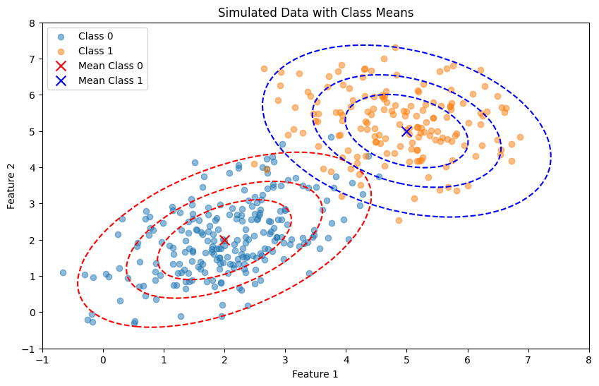

```python
import numpy as np
import matplotlib.pyplot as plt
from scipy.stats import multivariate_normal

# Set random seed for reproducibility
np.random.seed(42)

# Parameters for Class 0
mu_0 = np.array([2, 2])
sigma_0 = np.array([[1, 0.5], [0.5, 1]])

# Parameters for Class 1
mu_1 = np.array([5, 5])
sigma_1 = np.array([[1, -0.3], [-0.3, 1]])

# Generate data
n_samples = 400  # Total number of samples
prior_0 = 0.6  # Prior probability for class 0
prior_1 = 1 - prior_0  # Prior probability for class 1
# Sample class labels according to the prior
assignment = np.random.choice([0, 1], size=n_samples, p=[prior_0, prior_1])
# Count samples per class
n_samples_0 = np.sum(assignment == 0)
n_samples_1 = np.sum(assignment == 1)
X0 = np.random.multivariate_normal(mu_0, sigma_0, n_samples_0)
X1 = np.random.multivariate_normal(mu_1, sigma_1, n_samples_1)

# set up figure size
plt.figure(figsize=(10, 6))
# Plot data
plt.scatter(X0[:, 0], X0[:, 1], label='Class 0', alpha=0.5)
plt.scatter(X1[:, 0], X1[:, 1], label='Class 1', alpha=0.5)
# plot density contours
x, y = np.linspace(-3, 10, 100), np.linspace(-3, 10, 100)
X, Y = np.meshgrid(x, y)
pos = np.dstack((X, Y))
density0 = multivariate_normal(mu_0, sigma_0).pdf(pos)
density1 = multivariate_normal(mu_1, sigma_1).pdf(pos)
plt.contour(X, Y, density0, levels=[0.01, 0.05, 0.1], colors='r', linestyles='dashed')
plt.contour(X, Y, density1, levels=[0.01, 0.05, 0.1], colors='b', linestyles='dashed')
# plot means as crosses
plt.scatter(mu_0[0], mu_0[1], marker='x', color='r', s=100, label='Mean Class 0')
plt.scatter(mu_1[0], mu_1[1], marker='x', color='b', s=100, label='Mean Class 1')
plt.xlabel('Feature 1')
plt.ylabel('Feature 2')
plt.title('Simulated Data with Class Means')
plt.legend()
# set axis to [-3,8] and [-2,8]
plt.xlim([-1, 8])
plt.ylim([-1, 8])
plt.show()
```

To illustrate how the error changes as a function of $x$, we compute the Bayes error rate along the segment connecting $\mu_0$ and $\mu_1$.

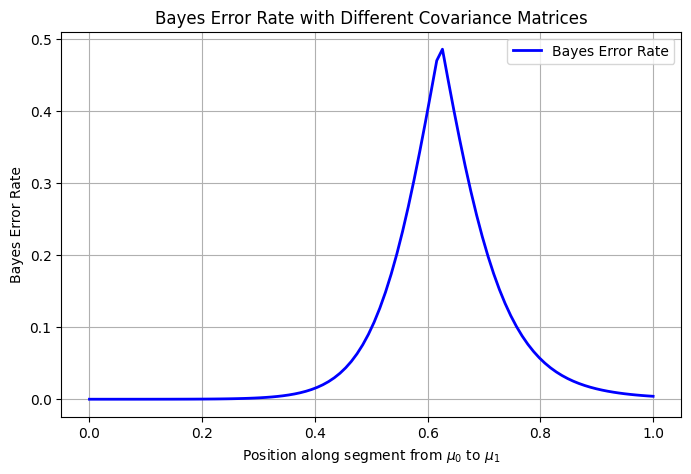

```python
# Generate points along the line connecting mu_0 and mu_1
t_values = np.linspace(0, 1, 100)
points = np.outer(1 - t_values, mu_0) + np.outer(t_values, mu_1)

# Compute class conditional densities with different covariances
pdf_0 = multivariate_normal.pdf(points, mean=mu_0, cov=sigma_0)
pdf_1 = multivariate_normal.pdf(points, mean=mu_1, cov=sigma_1)

# Compute posterior probabilities (assuming equal priors)
posterior_0 = (pdf_0 * prior_0) / (pdf_0 * prior_0 + pdf_1 * prior_1)
posterior_1 = (pdf_1 * prior_1) / (pdf_0 * prior_0 + pdf_1 * prior_1)

# Compute Bayes error rate at each point
bayes_error = 1 - np.maximum(posterior_0, posterior_1)

# Plot
plt.figure(figsize=(8, 5))
plt.plot(t_values, bayes_error, label="Bayes Error Rate", color="blue", linewidth=2)
plt.xlabel("Position along segment from $\mu_0$ to $\mu_1$")
plt.ylabel("Bayes Error Rate")
plt.title("Bayes Error Rate with Different Covariance Matrices")
plt.legend()
plt.grid(True)
plt.show()
```

Unfortunately we do not know the prior and likelihood to perform this calculations and achieve the Bayes optimal classifier. We thus have to make assumptions on the likelihoods and priors and further estimates their parameters to approximate the Bayes Classifier.

## Linear Discriminant Analysis

LDA assumes that the different classes generate data based on Gaussian distributions with means that are distinct but share the same covariance matrix. This assumption allows LDA to find a linear combination of features that characterizes or separates two or more classes of objects or events.

### Assumptions

- Data is drawn from **$k$** multivariate normal distributions, where each one of these distributions can have a different mean vector $\mu_k$, but all share the same covariance structure $\Sigma$

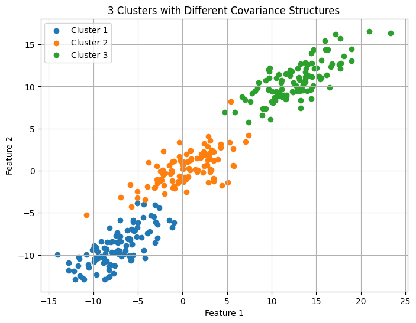

```python
# Step 1: Generate cluster centers
centers = [[-1, -4], [0, 0], [3, 4]]  # Define centers for 3 clusters
X, labels = make_blobs(n_samples=300, centers=centers, cluster_std=1, random_state=42)

# Step 2: Apply covariance matrices to each cluster (FEEL FREE TO PLAY AROUND WITH THESE)
# Define covariance matrices
# NOTE: These are technically cholesky factors of the the covariance matrix.
# NOTE: Cov(AX) = AA^T
chol_covariances = [
    np.array([[3, 1],
              [1, 2]]),  # Covariance for the first cluster
    np.array([[3, 1],
              [1, 2]]),  # Covariance for the second cluster
    np.array([[3, 1],
              [1, 2]])  # Covariance for the third cluster
]


# Initialize an empty array for transformed data
transformed_X = np.zeros(X.shape)

for label, cov in zip(range(len(centers)), chol_covariances):
    # Select data points belonging to the current cluster
    cluster_data = X[labels == label]
    # Apply the covariance matrix (linear transformation)
    transformed_cluster_data = cluster_data.dot(cov)
    # Store the transformed data back
    transformed_X[labels == label] = transformed_cluster_data

# Plotting
plt.figure(figsize=(8, 6))
for label, cov, center in zip(range(len(centers)), chol_covariances, centers):
    # Plot each cluster using transformed data
    plt.scatter(transformed_X[labels == label][:, 0], transformed_X[labels == label][:, 1], label=f"Cluster {label + 1}")

plt.title("3 Clusters with Different Covariance Structures")
plt.xlabel("Feature 1")
plt.ylabel("Feature 2")
plt.legend()
plt.grid(True)
plt.show()
```

You can show that the Bayes classifier assigns class $k$ to observation $X=x$ if:

$$ \delta_k(x) = x^{T}\Sigma^{-1}\mu_k-\frac{1}{2} \mu_k^{T}\Sigma^{-1}\mu_k+ \log \pi_k $$

is the largest among the $\{\delta_1(x), \delta_2(x), \cdots, \delta_k(x)\}$. This will determine regions that partition the space, decision boundaries, and a new point will be classified according to the region it is contained in.

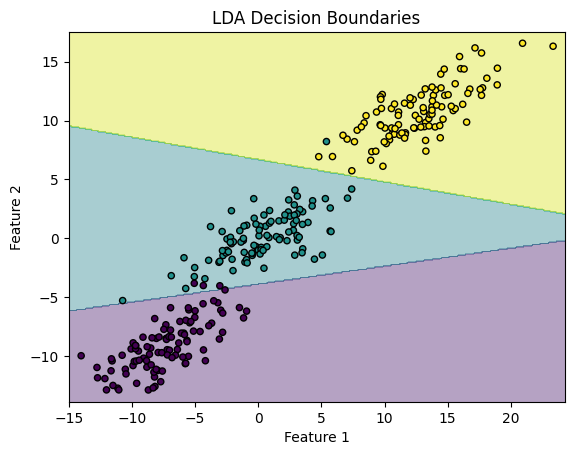

```python
# Step 3: Train LDA on the transformed data
lda = LDA()
lda.fit(transformed_X, labels)

# Step 4: Visualize the decision boundaries
# Create a mesh to plot the decision boundaries
x_min, x_max = transformed_X[:, 0].min() - 1, transformed_X[:, 0].max() + 1
y_min, y_max = transformed_X[:, 1].min() - 1, transformed_X[:, 1].max() + 1
xx, yy = np.meshgrid(np.arange(x_min, x_max, 0.1),
                     np.arange(y_min, y_max, 0.1))

# Predict the class for each mesh point
Z = lda.predict(np.c_[xx.ravel(), yy.ravel()])
Z = Z.reshape(xx.shape)

# Plot the decision boundaries
plt.contourf(xx, yy, Z, alpha=0.4)
plt.scatter(transformed_X[:, 0], transformed_X[:, 1], c=labels, s=20, edgecolor='k')

plt.title('LDA Decision Boundaries')
plt.xlabel('Feature 1')
plt.ylabel('Feature 2')
plt.show()
```

## Group Work: LDA (22 points)

### Question 1 (2 points)

What is the Bayes Classifier? Give the definition.

**ANSWER**: The **Bayes Classifier** is the theoretical optimal classifier that minimizes the probability of misclassification. It assigns a new observation $ X $ to the class $ k $ that has the highest posterior probability:

$$ P(Y = k \mid X = x) = \frac{P(X = x \mid Y = k) P(Y = k)}{P(X = x)} $$

By Bayes' Theorem, the **Bayes Classifier** assigns $ X $ to the class:

$$ \hat{Y} = \arg\max_k P(Y = k \mid X = x) $$

where:

- $ P(Y = k) $ is the prior probability of class $ k $,
- $ P(X = x \mid Y = k) $ is the class-conditional density,
- $ P(X = x) $ is the marginal density of $ X $.

### Question 2 (4 points)

Implement the discriminant function for LDA from above.

```python
# Discriminant function for LDA
def discriminant(x: np.ndarray, mu_k: np.ndarray, sigma: np.ndarray, pi: float) -> float:
    """
    Computes the LDA discriminant function for class k.

    Parameters:
    x (np.ndarray): The input data point (d-dimensional).
    mu_k (np.ndarray): Mean vector of class k (d-dimensional).
    sigma (np.ndarray): Shared covariance matrix (d x d).
    pi (float): Prior probability of class k.

    Returns:
    np.ndarray: The discriminant score for class k.
    """

    ### IMPLEMENT SOLUTIION HERE
    sigma_inv = np.linalg.inv(sigma)
    return x.T @ sigma_inv @ mu_k - 0.5 * mu_k.T @ sigma_inv @ mu_k + np.log(pi)
```

```python
### DO NOT EDIT (YOU WILL GET A 0 IF YOU DO)

# Test case 1:
x1 = np.array([1, 2])
mu_k1 = np.array([0, 0])
sigma1 = np.array([[1, 0], [0, 1]])
pi1 = 0.5
result1 = discriminant(x1, mu_k1, sigma1, pi1)
expected1 = -0.69314718056
assert np.isclose(result1, expected1), f"Test case 1 failed: {result1} != {expected1}"

# Test case 3:
x3 = np.array([1, 2, 3])
mu_k3 = np.array([0, 0, 0])
sigma3 = np.array([[1, 0, 0], [0, 1, 0], [0, 0, 1]])
pi3 = 0.3
result3 = discriminant(x3, mu_k3, sigma3, pi3)
expected3 = -1.2039728043259361
assert np.isclose(result3, expected3), f"Test case 3 failed: {result3} != {expected3}"

# Test case 4:
x4 = np.array([1, 2])
mu_k4 = np.array([2, 2])
sigma4 = np.array([[1, 0], [0, 1]])
pi4 = 1.0
result4 = discriminant(x4, mu_k4, sigma4, pi4)
expected4 = 2
assert np.isclose(result4, expected4), f"Test case 4 failed: {result4} != {expected4}"

# Test case 5: Edge case - zero input
x5 = np.array([0, 0])
mu_k5 = np.array([1, 1])
sigma5 = np.array([[1, 0], [0, 1]])
pi5 = 0.5
result5 = discriminant(x5, mu_k5, sigma5, pi5)
expected5 = -0.5 * (1 + 1) + np.log(0.5)  # Constant term only
assert np.isclose(result5, expected5), f"Test case 5 failed: {result5} != {expected5}"

# Test case 6: Non-identity covariance matrix
d = 20
np.random.seed(42)
x = np.random.normal(size = d)
mu_k = np.random.normal(size = d)
sigma = np.random.normal(size = (d, d))
sigma = sigma.dot(sigma.T)
pi = np.random.rand()

result6 = discriminant(x, mu_k, sigma, pi)
expected6 = -0.22459130958043083
assert np.isclose(result6, expected6), f"Test case 6 failed: {result6} != {expected6}"

print("All tests passed!")
```

```
All tests passed!
```

### Question 3 (2 points)

So now we make predictions by taking the maximal index of our discriminant function. Implement a function that returns the correct index.

```python
def predict(x: np.ndarray, mu: np.ndarray, sigma: np.ndarray, pi: np.ndarray) -> int:
    """
    Computes the predicted index in LDA.

    Parameters:
    x (np.ndarray): The input data point. shape = (d,)
    mu (np.ndarray): Mean vectors of classes. shape = (k, d)
    sigma (np.ndarray): Shared covariance matrix. shape = (d, d)
    pi (np.ndarray): Prior probabilities. shape = (k,)

    Returns:
    int: The index of the predicted class.
    """

    ### IMPLEMENT SOLUTIION HERE
    discriminants = [discriminant(x, mu[i], sigma, pi[i]) for i in range(mu.shape[0])]
    return np.argmax(discriminants)
```

```python
### DO NOT EDIT (YOU WILL GET A 0 IF YOU DO)

# Test case 1: Simple 2D example with two classes
x_test = np.array([1, 2])  # Test point
mu_test = np.array([[0, 0], [2, 2]])  # Means for two classes
sigma_test = np.array([[1, 0.2], [0.2, 1]])  # Shared covariance matrix
pi_test = np.array([0.5, 0.5])  # Equal priors

# Expected prediction: Compute discriminant scores
expected_class_1 = 1
result_1 = predict(x_test, mu_test, sigma_test, pi_test)
assert result_1 == expected_class_1, f"Test case 1 failed: expected {expected_class_1}, got {result_1}"
print(f"Test case 1 PASSED: expected {expected_class_1}, got {result_1}")

# Test case 2: Higher-dimensional case with three classes
x_test = np.array([3, 2, 1])
mu_test = np.array([[1, 1, 1], [4, 4, 4], [0, 0, 0]])  # Three classes
sigma_test = np.array([[1, 0.1, 0.2], [0.1, 1, 0.3], [0.2, 0.3, 1]])  # Shared covariance
pi_test = np.array([0.4, 0.4, 0.2])  # Different priors

# Expected prediction: Compute discriminant scores
expected_class_2 = 0
result_2 = predict(x_test, mu_test, sigma_test, pi_test)
assert result_2 == expected_class_2, f"Test case 2 failed: expected {expected_class_2}, got {result_2}"
print(f"Test case 2 PASSED: expected {expected_class_2}, got {result_2}")

# Test case 3: Edge case where priors are highly imbalanced
x_test = np.array([-1, -1])
mu_test = np.array([[1, 1], [-1, -1]])  # Two classes
sigma_test = np.array([[1, 0], [0, 1]])  # Identity covariance
pi_test = np.array([0.9, 0.1])  # Class 0 has a much higher prior

# Expected prediction: Compute discriminant scores
expected_class_3 = 1
result_3 = predict(x_test, mu_test, sigma_test, pi_test)
assert result_3 == expected_class_3, f"Test case 3 failed: expected {expected_class_3}, got {result_3}"
print(f"Test case 3 PASSED: expected {expected_class_3}, got {result_3}")

print("All test cases passed!")
```

```
Test case 1 PASSED: expected 1, got 1
Test case 2 PASSED: expected 0, got 0
Test case 3 PASSED: expected 1, got 1
All test cases passed!
```

### Question 4 (4 points)

Using for loops is quite slow. Implement a vectorized function that directly returns an array of discriminants.

**HINT**: You can use `np.einsum` to perform the computation of each of the two terms of the discriminants in one single call. **If you have not used `np.einsum` before** you can refer to [this notebook](https://colab.research.google.com/drive/1cGKbSheg33GhRnbAvWcozptL59MjgdLM?usp=sharing) for examples and explanations.

```python
def discriminant_scores(x: np.ndarray, mu: np.ndarray, sigma: np.ndarray, pi: np.ndarray) -> np.ndarray:
    """
    Computes all discriminant scores for LDA.

    Parameters:
    x (np.ndarray): The input data point. shape = (d,)
    mu (np.ndarray): Mean vectors of classes. shape = (k, d)
    sigma (np.ndarray): Shared covariance matrix. shape = (d, d)
    pi (np.ndarray): Prior probabilities. shape = (k,)

    Returns:
    np.ndarray: An array of discriminant scores. shape = (k,)
    """

    ### IMPLEMENT SOLUTIION HERE
    sigma_inv = np.linalg.inv(sigma)

    item1 = np.einsum('i,ij,ki->k', x, sigma_inv, mu)
    item2 = -0.5 * np.einsum('kj,ij,ki->k', mu, sigma_inv, mu)
    return item1 + item2 + np.log(pi)
```

```python
def predict_vectorized(x: np.ndarray, mu: np.ndarray, sigma: np.ndarray, pi: np.ndarray) -> int:
    ### IMPLEMENT SOLUTIION HERE
    discriminants = discriminant_scores(x, mu, sigma, pi)
    return np.argmax(discriminants)
```

```python
### DO NOT EDIT (YOU WILL GET A 0 IF YOU DO)

# Test case 1: Simple 2D example with two classes
x_test = np.array([1, 2])  # Test point
mu_test = np.array([[0, 0], [2, 2]])  # Means for two classes
sigma_test = np.array([[1, 0.2], [0.2, 1]])  # Shared covariance matrix
pi_test = np.array([0.5, 0.5])  # Equal priors

# Expected prediction: Compute discriminant scores
expected_class_1 = 1
result_1 = predict_vectorized(x_test, mu_test, sigma_test, pi_test)
assert result_1 == expected_class_1, f"Test case 1 failed: expected {expected_class_1}, got {result_1}"
print(f"Test case 1 PASSED: expected {expected_class_1}, got {result_1}")

# Test case 2: Higher-dimensional case with three classes
x_test = np.array([3, 2, 1])
mu_test = np.array([[1, 1, 1], [4, 4, 4], [0, 0, 0]])  # Three classes
sigma_test = np.array([[1, 0.1, 0.2], [0.1, 1, 0.3], [0.2, 0.3, 1]])  # Shared covariance
pi_test = np.array([0.4, 0.4, 0.2])  # Different priors

# Expected prediction: Compute discriminant scores
expected_class_2 = 0
result_2 = predict_vectorized(x_test, mu_test, sigma_test, pi_test)
assert result_2 == expected_class_2, f"Test case 2 failed: expected {expected_class_2}, got {result_2}"
print(f"Test case 2 PASSED: expected {expected_class_2}, got {result_2}")

# Test case 3: Edge case where priors are highly imbalanced
x_test = np.array([-1, -1])
mu_test = np.array([[1, 1], [-1, -1]])  # Two classes
sigma_test = np.array([[1, 0], [0, 1]])  # Identity covariance
pi_test = np.array([0.9, 0.1])  # Class 0 has a much higher prior

# Expected prediction: Compute discriminant scores
expected_class_3 = 1
result_3 = predict_vectorized(x_test, mu_test, sigma_test, pi_test)
assert result_3 == expected_class_3, f"Test case 3 failed: expected {expected_class_3}, got {result_3}"
print(f"Test case 3 PASSED: expected {expected_class_3}, got {result_3}")

print("All test cases passed!")
```

```
Test case 1 PASSED: expected 1, got 1
Test case 2 PASSED: expected 0, got 0
Test case 3 PASSED: expected 1, got 1
All test cases passed!
```

### Question 5 (3 points)

Now let us vectorize the function also over the datapoints $x$.

**HINT**: You can use `np.einsum` to perform the computation of each of the two terms of the discriminants in one single call. **If you have not used `np.einsum` before** you can refer to [this notebook](https://colab.research.google.com/drive/1cGKbSheg33GhRnbAvWcozptL59MjgdLM?usp=sharing) for examples and explanations.

```python
def discriminant_scores(x: np.ndarray, mu: np.ndarray, sigma: np.ndarray, pi: np.ndarray) -> np.ndarray:
    """
    Computes all discriminant scores for LDA at several datapoints.

    Parameters:
    x (np.ndarray): The input data point. shape = (n, d)
    mu (np.ndarray): Mean vectors of classes. shape = (k, d)
    sigma (np.ndarray): Shared covariance matrix. shape = (d, d)
    pi (np.ndarray): Prior probabilities. shape = (k,)

    Returns:
    np.ndarray: An array of discriminant scores. shape = (n, k)
    """
    ### IMPLEMENT SOLUTION HERE

    sigma_inv = np.linalg.inv(sigma)

    # For each datapoint i and class j, term1[i, j] = x[i]^T * sigma_inv * mu[j]
    term1 = np.einsum('id,dm,jm->ij', x, sigma_inv, mu)

    # For each class j, term2[j] = mu[j]^T * sigma_inv * mu[j]
    term2 = np.einsum('kd,dm,km->k', mu, sigma_inv, mu)
    scores = term1 - 0.5 * term2 + np.log(pi)
    return scores
```

```python
def predict_vectorized(x: np.ndarray, mu: np.ndarray, sigma: np.ndarray, pi: np.ndarray) -> int:
    ### IMPLEMENT SOLUTION HERE
    discriminants = discriminant_scores(x, mu, sigma, pi)
    return np.argmax(discriminants, axis=1)
```

```python
### DO NOT EDIT (YOU WILL GET A 0 IF YOU DO)

# Test case 1
n = 4
d = 3
k = 2
np.random.seed(503)
x = np.random.normal(size = (n, d))
mu = np.random.normal(size = (k, d))
sigma = np.random.normal(size = (d, d))
sigma = sigma.dot(sigma.T)
pi = np.random.rand(k)

result = discriminant_scores(x, mu, sigma, pi)
expected = np.array([[-0.79650917, -1.79941157],
 [-0.63978301,  2.06795532],
 [ 0.10567327,  1.54700591],
 [ 0.04314746,  1.44296768]]
)
assert np.allclose(result, expected), f"Test case 1 failed: {result} != {expected}"

# Test case 2
n = 100
d = 20
k = 5
np.random.seed(42)
x = np.random.normal(size = (n, d))
mu = np.random.normal(size = (k, d))
sigma = np.random.normal(size = (d, d))
sigma = sigma.dot(sigma.T)
pi = np.random.rand(k)

result = discriminant_scores(x, mu, sigma, pi)

assert result.shape == (n, k), f"Test case failed: shape {result.shape} != {(n, k)}"
print(f"Test case PASSED: shape {result.shape} == {(n, k)}")

assert np.isclose(result.mean(), -41.130043376305416), f"Test case failed: mean {result.mean()} != {-41.130043376305416}"
print(f"Test case PASSED: mean {result.mean()} == {-41.130043376305416}")

assert np.isclose(result.std(), 95.2601173142212), f"Test case failed: std {result.std()} != {95.2601173142212}"
print(f"Test case PASSED: std {result.std()} == {95.2601173142212}")

assert np.isclose(result.min(), -525.4935904371674), f"Test case failed: min {result.min()} != {-525.4935904371674}"
print(f"Test case PASSED: min {result.min()} == {-525.4935904371674}")

assert np.isclose(result.max(), 252.6084971655994), f"Test case failed: max {result.max()} != {252.6084971655994}"
print(f"Test case PASSED: max {result.max()} == {252.6084971655994}")

print("All test cases passed!")
```

```
Test case PASSED: shape (100, 5) == (100, 5)
Test case PASSED: mean -41.130043376305416 == -41.130043376305416
Test case PASSED: std 95.2601173142212 == 95.2601173142212
Test case PASSED: min -525.4935904371674 == -525.4935904371674
Test case PASSED: max 252.6084971655994 == 252.6084971655994
All test cases passed!
```

### Question 6 (1 point)

We now know how to predict datapoints with a list of means, a covariance matrix and a vector of prior probabilities.

LDA starts off by estimating all of these. How many parameters are estimated with $k$ classes and $d$ dimensions?

**ANSWER**:

$$k\times d + \cfrac{d(d+1)}{2}+(k-1)$$

### Question 7 (3 points)

Write a function that takes in $X$, $y$ and computes all parameters using $$ \mu_k = \frac{1}{\#\{y_i = k\}}\sum_{y_i = k} x_i\\ \Sigma = \frac{1}{n - K} \sum_{k=1}^{K} \sum_{y_i = k} (x_i - \mu_k)(x_i - \mu_k)^T \\ \pi_k = \frac{\#\{y_i = k\}}{n} $$ where:

- $\mu_k$ is the mean vector for class $k$
- $\Sigma$ is the shared covariance matrix
- $\pi_k$ is the prior probability of class $k$

```python
from typing import Tuple

# LDA estimator
def lda_estimator(X: np.ndarray, y: np.ndarray) -> Tuple[np.ndarray, np.ndarray, np.ndarray]:
    """
    Estimates the parameters for Linear Discriminant Analysis (LDA).

    Parameters:
    X: np.ndarray, shape = (n, d). Feature matrix for n samples.
    y: np.ndarray, shape = (n,). Class labels for n samples.

    Returns:
    mu: np.ndarray, shape = (k, d) - Mean vectors for each class.
    sigma: np.ndarray, shape = (d, d) - Shared covariance matrix.
    pi: np.ndarray, shape = (k,) - Prior probabilities for each class.
    """

    ### IMPLEMENT SOLUTION HERE
    k = len(np.unique(y))
    n, d = X.shape
    mu = np.zeros((k, d))
    sigma = np.zeros((d, d))
    pi = np.zeros(k)
    for i in range(k):
        mu[i] = np.mean(X[y == i], axis=0)
        pi[i] = np.sum(y == i) / n
        sigma += np.dot((X[y == i] - mu[i]).T, (X[y == i] - mu[i]))
    sigma /= n - k
    return mu, sigma, pi
```

```python
### DO NOT EDIT (YOU WILL GET A 0 IF YOU DO)

# Generate random test dataset
np.random.seed(42)  # For reproducibility

n_samples_per_class = 50  # Number of samples per class
d = 2  # Number of features
k = 2  # Number of classes

# Generate random means for each class
mu_true = np.array([[2, 3], [9, 8]])  # True means for class 0 and class 1
sigma_true = np.array([[1, 0.5], [0.5, 1]])  # Shared covariance matrix

# Generate random data
X_class_0 = np.random.multivariate_normal(mu_true[0], sigma_true, n_samples_per_class)
X_class_1 = np.random.multivariate_normal(mu_true[1], sigma_true, n_samples_per_class)

# Combine data
X_test = np.vstack([X_class_0, X_class_1])
y_test = np.hstack([np.zeros(n_samples_per_class, dtype=int), np.ones(n_samples_per_class, dtype=int)])  # Labels (int)

# Compute LDA parameters
mu_test, sigma_test, pi_test = lda_estimator(X_test, y_test)

# Expected values (computed from generated data)
expected_mu = np.array(
    [[2.15350725, 3.08148984],
     [9.01263359, 8.15269564]]
)  # Empirical means
expected_pi = np.array([0.5, 0.5])
expected_sigma = np.array(
    [[0.82666485, 0.30615014],
     [0.30615014, 0.78206076]]
)

# Assertion Tests
assert np.allclose(mu_test, expected_mu, atol=1e-2), f"Test failed: Expected mu {expected_mu}, got {mu_test}"
assert np.allclose(pi_test, expected_pi, atol=1e-2), f"Test failed: Expected pi {expected_pi}, got {pi_test}"
assert np.allclose(sigma_test, expected_sigma, atol=1e-2), f"Test failed: Expected sigma {sigma_true}, got {sigma_test}"

print("All tests passed!")
```

```
All tests passed!
```

### Question 8 (3 points)

Now we can implement LDA fully. Use the functions we wrote above to fill in this class.

```python
class LDA:
    def __init__(self):
        self.mu = None
        self.sigma = None
        self.pi = None

    def fit(self, X: np.ndarray, y: np.ndarray) -> None:
        """
        Estimates the parameters for Linear Discriminant Analysis (LDA).

        Parameters:
        X: np.ndarray, shape = (n, d). Feature matrix for n samples.
        y: np.ndarray, shape = (n,). Class labels for n samples.

        Returns:
        None
        """
        ### IMPLEMENT SOLUTION HERE (Hint: Plug in what you already implemented.)
        n, d = X.shape
        classes = np.unique(y)
        k = len(classes)

        self.mu = np.array([X[y == cls].mean(axis=0) for cls in classes])

        self.pi = np.array([np.mean(y == cls) for cls in classes])

        self.sigma = np.zeros((d, d))
        for cls, mu_k in zip(classes, self.mu):
            X_k = X[y == cls]
            centered_X = X_k - mu_k
            self.sigma += centered_X.T @ centered_X
        self.sigma /= (n - k)

    def discriminant_scores(self, x: np.ndarray) -> np.ndarray:
        """
        Computes the discriminant scores for LDA.

        Parameters:
        x: np.ndarray, shape = (n, d). Feature matrix for n samples
        mu: np.ndarray, shape = (k, d) - Mean vectors for each class.
        sigma: np.ndarray, shape = (d, d) - Shared covariance matrix.
        pi: np.ndarray, shape = (k,) - Prior probabilities for each class.

        Returns:
        np.ndarray, shape = (n, k) - Discriminant scores for each class.
        """
        ### IMPLEMENT SOLUTION HERE (Hint: Plug in what you already implemented.)
        sigma_inv = np.linalg.inv(self.sigma)
        linear_term = np.einsum('li,ij,ki -> lk', x, sigma_inv, self.mu)
        constant_term = -0.5 * np.einsum('kj,ij,ki -> k', self.mu, sigma_inv, self.mu) + np.log(self.pi)
        return linear_term + constant_term

    def predict(self, X: np.ndarray) -> np.ndarray:
        """
        Predicts class labels for given data points.

        Parameters:
        X: np.ndarray, shape = (n, d). Feature matrix for n samples.

        Returns:
        np.ndarray, shape = (n,). Predicted class labels for n samples.
        """
        ### IMPLEMENT SOLUTION HERE (Hint: Plug in what you already implemented.)
        scores = self.discriminant_scores(X)
        return np.argmax(scores, axis=1)
```

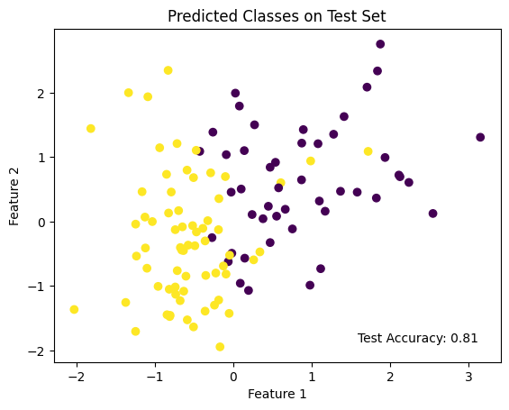

```python
# DO NOT MODIFY

from sklearn.datasets import load_breast_cancer
from sklearn.model_selection import train_test_split
from sklearn.preprocessing import StandardScaler
import matplotlib.pyplot as plt


# fit LDA on breast_cancer and plot predicted classes on a test set

# load data
data = load_breast_cancer()
# scale X
X = StandardScaler().fit_transform(data.data)
y = data.target

# split
X_train, X_test, y_train, y_test = train_test_split(X, y, test_size=0.2, random_state=42)

# fit LDA
lda = LDA()
lda.fit(X_train, y_train)

# predict
y_pred = lda.predict(X_test)

# plot
plt.scatter(X_test[:, 0], X_test[:, 1], c=y_pred, cmap='viridis')
plt.title('Predicted Classes on Test Set')
plt.xlabel('Feature 1')
plt.ylabel('Feature 2')
# print test accuracy on bottom right
plt.text(0.95, 0.05, f'Test Accuracy: {1 - np.mean(y_pred != y_test):.2f}', transform=plt.gca().transAxes, ha='right', va='bottom')
plt.show()
```

## Quadratic Discriminant Analysis

### Assumptions

- Data is drawn from **$k$** multivariate normal distributions, where each one of these distributions can have a different mean vector $\mu_k$, and each can have different covariance structure $\Sigma_k$.

QDA allows for each class to have its own covariance matrix, making it a more flexible approach that can capture more complex structures. However, it requires estimating more parameters and thus may not perform as well as LDA when the amount of training data is limited. In this case, the boundaries are determined by the Bayes classifier that assigns class $k$ to observation $x$ if:

$$ \delta_k(x) = -\frac{1}{2}x^{T}\Sigma^{-1}_k x_k+x^{T}\Sigma^{-1}_k\mu_k-\frac{1}{2} \mu_k^{T}\Sigma^{-1}_k\mu_k+ \log \pi_k $$

Is the largest among the $\{\delta_1(x), \delta_2(x), \cdots, \delta_k(x)\}$. Analogous to LDA, this will induce a partition of the space.

## Group Work: QDA (8 points)

### Question 9 (2 points)

How many parameters do you have to etimate in QDA?

**ANSWER:** Parameters in QDA

In Quadratic Discriminant Analysis (QDA), we need to estimate the following parameters for each class k:

1. Mean Vector ($μk$): Represents the average value of each feature within class k. It has d parameters, where d is the number of features.
2. Covariance Matrix ($Σk$): Captures the relationships between features within class k. It's a d x d matrix, but since it's symmetric, we only need to estimate d(d + 1)/2 unique parameters.
3. Prior Probability ($πk$): Represents the probability of observing a data point from class k.

Total Parameters

If we have K classes and d features, the total number of parameters to estimate in QDA is:

1. $K * d$ (for the mean vectors of all classes)
2. $K * d(d + 1)/2$ (for the covariance matrices of all classes)
3. $K - 1$ (for the prior probabilities, since the last one can be deduced from the others)

Therefore, the total number of parameters to estimate in QDA is:

$$K * [d + d(d + 1)/2] + (K - 1)$$

### Question 10 (SETUP: 2 points)

Fit QDA using `sklearn` on the NHANES dataset. Pick two features and focus on HDL as an outcome. Similarly to the previous Group Work assignment, threshold HDL to generate labels. We will have three groups:

- group 0: HDL < 40
- group 1: 40 <= HDL < 70
- group 2: HDL >= 70

Before fitting the model, we will scale our data and split it in train and test datasets.

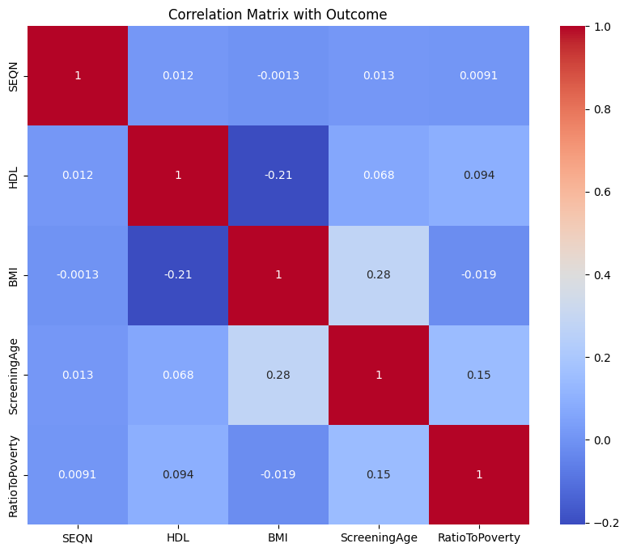

```
Accuracy: 0.7466442953020134
```

```python
from sklearn.discriminant_analysis import QuadraticDiscriminantAnalysis as QDA
from sklearn.model_selection import train_test_split
from sklearn.preprocessing import StandardScaler
import seaborn as sns

# import NHANES
hdl = pd.read_sas('HDL_L.xpt')
bmx = pd.read_sas('BMX_L.xpt')
demo = pd.read_sas('DEMO_L.xpt')

# join on SEQN
df = pd.merge(hdl, bmx, on='SEQN', how='inner')
df = pd.merge(df, demo, on='SEQN', how='inner')

# only keep relevant features
my_df = df[["SEQN", "LBDHDD", "BMXBMI", "RIDAGEYR", "INDFMPIR"]]
my_df = my_df.rename(columns={"LBDHDD": "HDL", "BMXBMI": "BMI", "INDFMPIR": "RatioToPoverty", "RIDAGEYR": "ScreeningAge"})

# remove NAs
my_df = my_df.dropna()

# threshold HDL
my_df['HDL'] = pd.cut(my_df['HDL'], bins=[-float('inf'), 40, 70, float('inf')], labels=[0, 1, 2], right=False)

# plot correlation matrix with outcome
plt.figure(figsize=(10, 8))
sns.heatmap(my_df.corr(), annot=True, cmap='coolwarm')
plt.title('Correlation Matrix with Outcome')
plt.show()

# features and labels
X, y = my_df[["BMI", "RatioToPoverty"]], my_df["HDL"]
# scale the data
scaler = StandardScaler()
X = scaler.fit_transform(X)
# train test split
X_train, X_test, y_train, y_test = train_test_split(X, y, test_size=0.2, random_state=42)
# fit QDA
qda = QDA()
qda.fit(X_train, y_train)
# predict
y_pred = qda.predict(X_test)
# accuracy
print(f"Accuracy: {np.mean(y_pred == y_test)}")
```

### Question 11 (4 points)

Similarly to how we plotted the decision boundary for LDA. Do the same for the QDA we fitted.

```python
# Set min and max values and give it some padding
x_min, x_max = X[:, 0].min() - 1, X[:, 0].max() + 1
y_min, y_max = X[:, 1].min() - 1, X[:, 1].max() + 1
```

```python
h = 0.02  # step size in the mesh
# Generate a grid of points with distance h between them
xx, yy = np.meshgrid(np.arange(x_min, x_max, h), np.arange(y_min, y_max, h))
```

```python
# Predict the function value for the whole grid and RESHAPE your Z
### IMPLEMENT SOLUTION HERE
Z = qda.predict(np.c_[xx.ravel(), yy.ravel()])
Z = Z.reshape(xx.shape)
```

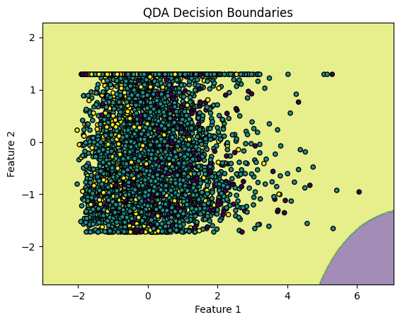

```python
# Plot the contour and training examples
plt.contourf(xx, yy, Z, alpha=0.5)
plt.scatter(X[:, 0], X[:, 1], c=y, s=20, edgecolor='k')
plt.title('QDA Decision Boundaries')
plt.xlabel('Feature 1')
plt.ylabel('Feature 2')
```